# Capstone: Exploratory Analysis

Javier Angoy

Jan 8th, 2018

## INTRODUCTION

Around the world, people are spending an increasing amount of time on their mobile devices for email, social networking, banking and a whole range of other activities. But typing on mobile devices can be a serious pain. A smart keyboard that makes it easier for people to type on their mobile devices. One cornerstone of the smart keyboards are predictive text models. In this capstone we will work on understanding and building predictive text models.

To start building a predictive model for text it is very important to understand the distribution and relationship between the words, tokens, and phrases in the text. The goal of this task is to understand the basic relationships in the data and prepare to build the first linguistic models.

The second goal is to build a simple model for the relationship between words. This is the first step in building a predictive text mining application.

This report describes in plain language, plots a preliminary exploratory analysis of the capstone data set.

## THE DATA

Text comes in three separated files: blog, news and twitter for each language.

Summary of source files

| File Name | N. Lines | N. Characters | Size |
| --- | --- | --- | --- |
| en_US.blogs.txt | 899288 | 206824505 | 200.4 MiB |
| en_US.news.txt | 1010242 | 203223159 | 196.3 MiB |
| en_US.twitter.txt | 2360148 | 162096241 | 159.4 MiB |

```
##    user  system elapsed
##  15.728   0.284  30.161
```

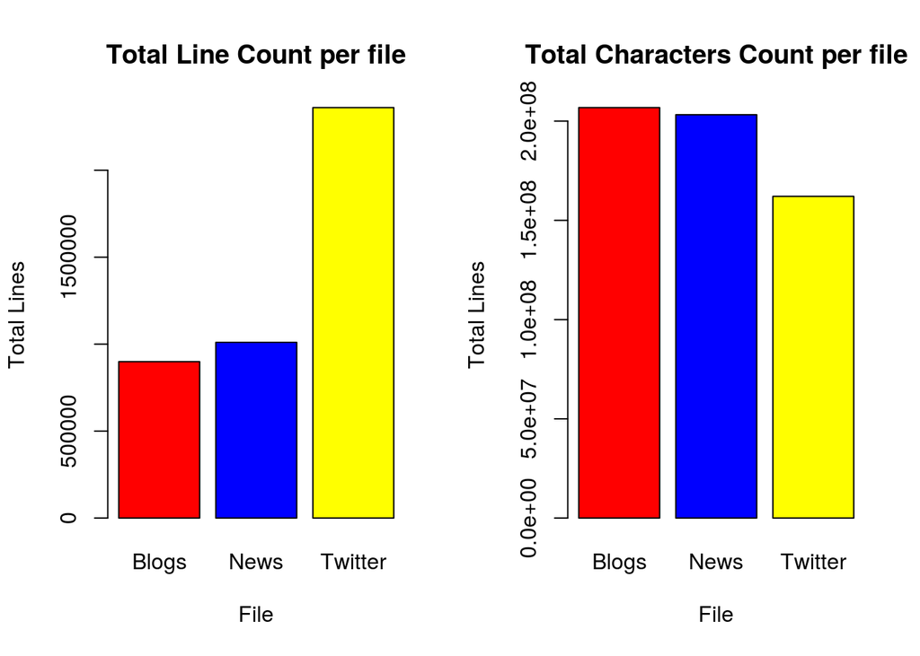

So we see that blogs have the least number of lines while the twitter data have the most. On the other side, blogs have more characters (and blog file size is bigger too).

## THE NEW CORPUS

Being the original files too bulky for our analysis, due to memory and processing time constrains, we will take a 10% sample from each file and gather the docs into a corpus. As our data analysis will be done through the English text, we choose only the “en_US” files and proceed. After that, a summary with the 10 first documents (lines) of the corpus is obtained.

```
## Corpus consisting of 426966 documents, showing 10 documents:
##
##    Text Types Tokens Sentences
##   text1    21     21         1
##   text2    16     17         1
##   text3    29     34         1
##   text4    11     11         1
##   text5    29     38         1
##   text6    35     44         1
##   text7    18     19         1
##   text8     8      8         1
##   text9    29     36         1
##  text10    65    129         4
##
## Source:  /media/Windows/Users/kakis/Documents/DOCS/Dropbox/Data Scientist Coursera/Projects/Capstone/* on x86_64 by javier
## Created: Sat Jan  6 12:22:50 2018
## Notes:
```

```
##    user  system elapsed
##  66.712   1.104  67.726
```

So we have a corpus with 426966 documents (lines).

### Data cleaning

Unlike other NLP methods that avoid some words like offensive words and empty words, our aim is to get the richest possible model. Therefore, we assume that the results will have more accuracy if the model takes into account all kind of vocabulary. To tidy data we will remove numbers (standalone), punctuation marks and other symbols, separators, twitter special chars (@ and #), hyphens and url addresses, as we will focus on words. Foreign language words or phrases will not be handled in any way.

### Basic Statistics to summarize features

We perform a summary of the main characteristics we can

Feature Statistics

| unigrams | bigrams | trigrams |
| --- | --- | --- |
| 179022 | 2631057 | 6253947 |

List of top 25 ngrams (unigrams, duograms and trigrams)

| the | 477,475 |
| --- | --- |
| to | 277,277 |
| and | 242,397 |
| a | 239,291 |
| of | 201,903 |
| in | 165,991 |
| i | 165,466 |
| for | 110,507 |
| is | 107,715 |
| that | 104,454 |
| you | 94,417 |
| it | 92,314 |
| on | 82,475 |
| with | 71,348 |
| was | 62,690 |
| my | 60,516 |
| at | 57,167 |
| be | 55,107 |
| this | 54,694 |
| have | 53,097 |
| are | 49,205 |
| as | 48,498 |
| but | 48,432 |
| he | 43,161 |
| we | 42,260 |

| of the | 43,384 |
| --- | --- |
| in the | 41,536 |
| to the | 21,358 |
| for the | 20,113 |
| on the | 19,654 |
| to be | 16,169 |
| at the | 14,242 |
| and the | 12,910 |
| in a | 11,909 |
| with the | 10,838 |
| is a | 10,023 |
| it was | 9,608 |
| for a | 9,514 |
| from the | 8,688 |
| i have | 8,634 |
| i was | 8,565 |
| it is | 8,283 |
| and i | 8,261 |
| with a | 8,137 |
| will be | 8,127 |
| of a | 8,117 |
| going to | 8,090 |
| i am | 7,610 |
| have a | 7,433 |
| is the | 7,425 |

| one of the | 3,375 |
| --- | --- |
| a lot of | 3,018 |
| thanks for the | 2,409 |
| to be a | 1,774 |
| going to be | 1,726 |
| i want to | 1,519 |
| the end of | 1,453 |
| out of the | 1,445 |
| it was a | 1,399 |
| some of the | 1,391 |
| as well as | 1,384 |
| be able to | 1,289 |
| part of the | 1,253 |
| i have to | 1,146 |
| i have a | 1,142 |
| the rest of | 1,135 |
| i don’t know | 1,130 |
| is going to | 1,075 |
| looking forward to | 1,074 |
| this is a | 1,020 |
| the first time | 1,013 |
| thank you for | 995 |
| a couple of | 989 |
| i’m going to | 942 |
| end of the | 925 |

## PLOTS

### Top Features

Distributions of word frequencies

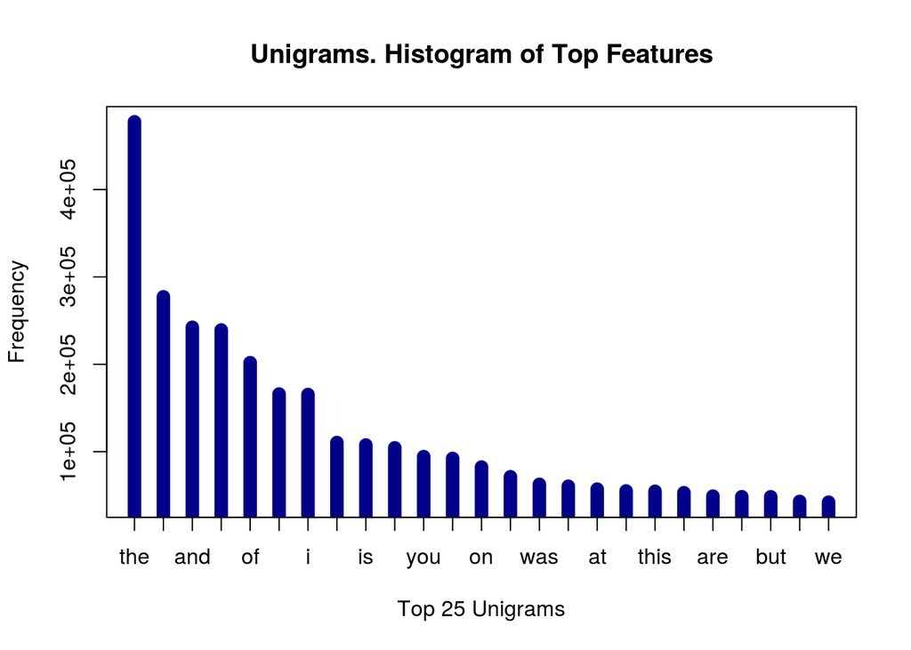

Frequencies of 2-grams and 3-grams in the dataset

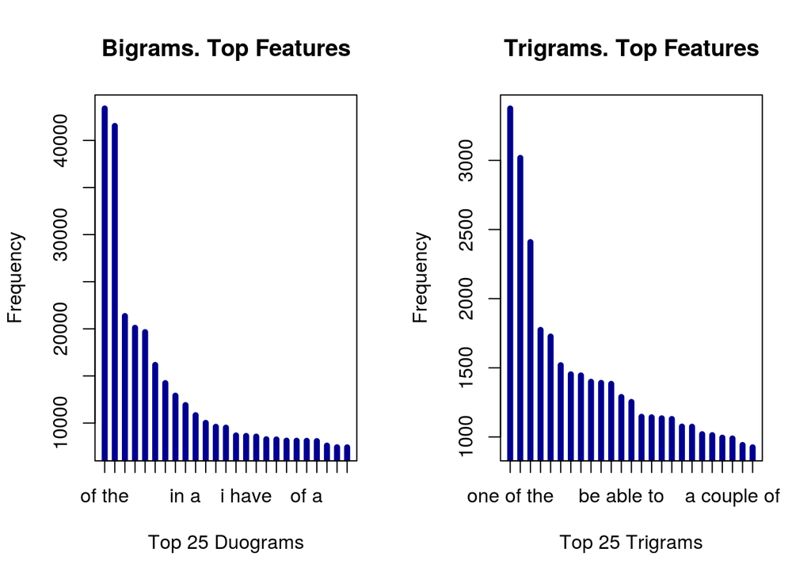

## Coverage 50% - 90%

Now we estimate the number of unique words that we need in our frequency sorted dictionary to cover 50% of all word instances in the language.

```
## [1] 143
```

And for 90%

```
## [1] 7466
```

So we see that we need 143 unique words to get an accuracy of 50%, and that 7466 will give to us a 90% accuracy.

## CONCLUSIONS

As we see a small number of words represents the bigger part of the corpus. Therefore, we can say that our model will not take much advantage of the most seldom features. Ignoring those less common features might make our model a bit resource efficient.

## NEXT STEPS

Next we will try to build a predictive model that explores the relationship between words in the more effective way we can. So we could try to do the same analysis up to bigger n-grams, may be 5. Memory usage and processing speed will be important tradeoffs however.

## APPENDIX. THE CODE

### Getting the data

```r
# Download zip file and decompress
if(!file.exists("./Project/Coursera-SwiftKey.zip")){
        download.file(url = "https://d396qusza40orc.cloudfront.net/dsscapstone/dataset/Coursera-SwiftKey.zip",
                      destfile= "./Coursera-SwiftKey.zip",
                      method = "curl")
    unzip("./Project/Coursera-SwiftKey.zip", overwrite = FALSE, exdir = "./Project")
    }
```

### Exploring the files

```r
ptm <- proc.time()

dirFiles <- paste0(getwd(),'/Project/final/en_US/')

# List all files in directory and extracts information
readF <- function(dirOpen){
    co <- 0 #just a counter
    finfo=data.frame(fname=character(), flen=integer(),
                     fchars=integer(),fsize=character(),stringsAsFactors = FALSE)
    listf <- list.files(path = dirOpen, full.names = T)
    #loop list of files, extract info
    parallel::mclapply(listf,function(fileOpen) {
        co <- 1 + co
        con <- file(fileOpen, "r", blocking = FALSE)
        lines <- readLines(con, skipNul = T)
        finfo[co,1] <- as.character(basename(fileOpen))
        finfo[co,2] <- length(lines)
        finfo[co,3] <- sum(nchar(lines))
        finfo[co,4] <- gdata::humanReadable(file.info(fileOpen)$size)
        close(con)
        return(finfo)
        })
}
info_table <- readF(dirFiles)
info_table <- rbind(info_table[[1]],info_table[[2]],info_table[[3]])
names(info_table)<- c("File Name","N. Lines","N. Characters","Size")
knitr::kable(info_table, caption = "Summary of source files")
proc.time() - ptm
```

```r
par(mfrow = c(1, 2))
barplot(info_table$`N. Lines`,
        names.arg = c("Blogs","News","Twitter"),
        col=c("red","blue","yellow"),
        xlab = 'File', ylab = 'Total Lines',
        main = "Total Line Count per file")
barplot(info_table$`N. Characters`,
        names.arg = c("Blogs","News","Twitter"),
        col=c("red","blue","yellow"),
        xlab = 'File', ylab = 'Total Lines',
        main = "Total Characters Count per file")
```

### Exploratory Analysis

```r
dirFiles <- paste0(getwd(),'/Project/final/')
copyLines <- function(dirOpen){
    dir_US <- paste0(dirOpen,'en_US/')
    fileConn <-paste0(dirOpen,'en_US.txt')
    listf <- list.files(path = dir_US, full.names = T)
    if (file.exists(fileConn)){file.remove(fileConn)}
    #loop list of files, open and copy 10% sample of lines to corpus
    parallel::mclapply(listf,function(fileOpen) {
        con <- file(fileOpen, "r", blocking = FALSE)
        lines <- readLines(con, skipNul = T)
        lines_copy <- sample(lines, size=length(lines)*0.1, replace=F)
        text <- tolower(lines_copy) #all text to lower
        close(con)
        return(text)
        })
}
set.seed(100)
mycorpus <- quanteda::corpus(unlist(copyLines(dirFiles)))
summary(mycorpus,10)
proc.time() - ptm
```

### Tokenize the texts, create n-grams

```r
tok <- tokens(mycorpus, verbose = TRUE,
       remove_numbers = TRUE, remove_punct = TRUE,
       remove_symbols = TRUE, remove_separators = TRUE,
       remove_twitter = TRUE, remove_hyphens = TRUE,
       remove_url = TRUE)
tokens_1 <- tokens(tok, ngrams = 1, concatenator = " ")
tokens_2 <- tokens(tok, ngrams = 2, concatenator = " ")
tokens_3 <- tokens(tok, ngrams = 3, concatenator = " ")
```

```r
unigrams <- dfm(tokens_1, verbose = TRUE)
duograms <- dfm(tokens_2, verbose = TRUE)
trigrams <- dfm(tokens_3, verbose = TRUE)
```

```r
df <- cbind(nfeature(unigrams),nfeature(duograms),nfeature(trigrams))
colnames(df) <-c("unigrams","bigrams","trigrams")
knitr::kable(df,style="html", caption = "Feature Statistics")
#summary
```

```r
ngram1 <- as.matrix(quanteda::topfeatures(unigrams, 25),dimnames=c("1gram","freq"))
ngram2 <- as.matrix(quanteda::topfeatures(duograms, 25),dimnames=c("2gram","freq"))
ngram3 <- as.matrix(quanteda::topfeatures(trigrams, 25),dimnames=c("3gram","freq"))

knitr::kable(list(ngram1,ngram2,ngram3), caption = "List of top 25 ngrams (unigrams, duograms and trigrams)",format.args = list(decimal.mark = ".", big.mark = ","), padding = 10,align = "c") %>%
  kable_styling(full_width = F)
```

### Coverage

```r
no_tokens <- sum(colSums(unigrams)) #total tokens
features_desc <- sort(colSums(unigrams), decreasing = TRUE) #sort features +-

rel_freq <- features_desc / no_tokens * 100 #calculates relative frequency vector
acum_rel_freq <- cumsum(rel_freq) #accumulated relative frequency
fcover_50 <- Position(function(x) x >= 50, acum_rel_freq) #features to cover 50%
print(fcover_50)
```

```r
fcover_90 <- Position(function(x) x >= 90, acum_rel_freq) #features to cover 90%
print(fcover_90)
```